# Statistical inference with the GSS data

## Setup

### Load packages

```r
library(ggplot2)
library(dplyr)
library(statsr)
```

### Load data

```r
load("gss.Rdata")
```

## Part 1: Data

The dataset used for this project is from the extact of the General Social Survey ([GSS](http://gss.norc.org)) Cumulative File 1972-2012. According to the codebook, a random sampling strategy was used therefore we can generalize the results to the US population

In addition, The study can be categorized as a random sampling observational study. Therefore, it will be difficult to draw causal conclusions based on the datasets since there is no random assignments or any experiments involved.

## Part 2: Research question

**Are older generations generally more opposed to homosexual sex relations than younger generations based on the dataset?**

I am interested to test the general public conception that older generations are more conservative and more against homosexual sex relations

## Part 3: Exploratory data analysis

We will use two columns to build my hypothesis for the research question

- **age**
- **homosexual**

The levels of response for the question “What about sexual relations between two adults of the same sex?” is as follows

```r
levels(gss$homosex)
```

```
## [1] "Always Wrong"     "Almst Always Wrg" "Sometimes Wrong"
## [4] "Not Wrong At All" "Other"
```

We will group people who answered either “Always Wrong” or “Almst Always Wrg” as people who are strongly against homosexual relations, and use the proportion **p** for the hypothesis test

```r
sub_df <- gss[, c("age", "homosex")]
sub_df <- sub_df[complete.cases(sub_df), ] # remove NA values

sub_df <- mutate(sub_df, against_homo=factor(ifelse(homosex=="Always Wrong" |homosex=="Almst Always Wrg", "yes", "No")))
summary(sub_df)
```

```
##       age                    homosex      against_homo
##  Min.   :18.00   Always Wrong    :21527   No : 9586
##  1st Qu.:31.00   Almst Always Wrg: 1575   yes:23102
##  Median :43.00   Sometimes Wrong : 2240
##  Mean   :45.58   Not Wrong At All: 7265
##  3rd Qu.:59.00   Other           :   81
##  Max.   :89.00
```

I will group the people into two age group based on the median age value

```r
sub_df <- mutate(sub_df, age_group=factor(ifelse(age>median(age), "older", "younger")))
summary(sub_df)
```

```
##       age                    homosex      against_homo   age_group
##  Min.   :18.00   Always Wrong    :21527   No : 9586    older  :16013
##  1st Qu.:31.00   Almst Always Wrg: 1575   yes:23102    younger:16675
##  Median :43.00   Sometimes Wrong : 2240
##  Mean   :45.58   Not Wrong At All: 7265
##  3rd Qu.:59.00   Other           :   81
##  Max.   :89.00
```

Group the data by people’s age group

```r
older <- sub_df[sub_df$age_group=="older", ]
younger <- sub_df[sub_df$age_group=="younger", ]
```

Construct a 95% confidence interval for the proportion of against-homo in the **older** generation

```r
inference(y = against_homo, data = older, statistic = "proportion", type = "ci", method = "theoretical", success = "yes")
```

```
## Single categorical variable, success: yes
## n = 16013, p-hat = 0.7706
## 95% CI: (0.764 , 0.7771)
```

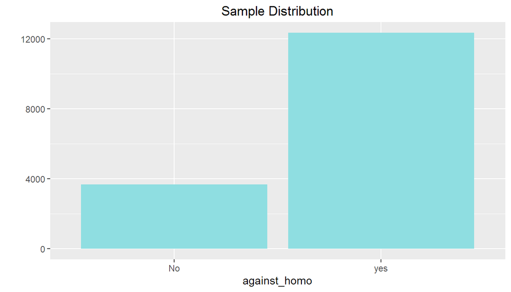

Next construct the 95% confidence interval for the proportion of against-homo in the **younger** generation

```r
inference(y = against_homo, data = younger, statistic = "proportion", type = "ci", method = "theoretical", success = "yes")
```

```
## Single categorical variable, success: yes
## n = 16675, p-hat = 0.6455
## 95% CI: (0.6382 , 0.6527)
```

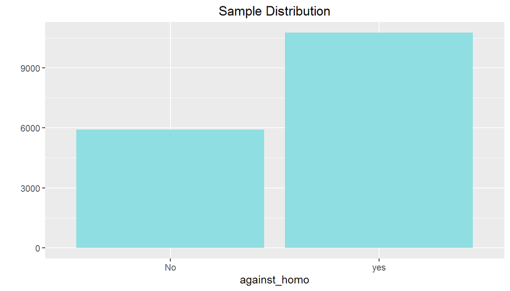

## Part 4: Inference

For this research question, we would like to make conclusions about the difference in the two population proportions. We will construct our hypothesis as follows:
$$H_0: p_{old} - p_{young} = 0$$
$$H_0: p_{old} - p_{young} >0$$
where p is the proportion of people who are against homosexual sex relations. Let’s start by check the conditions for using the normal model to analyse the result.

- The sample observations are independent
  - A random sampling was used and sample size is smaller than 10% of the population
- success-failure condition
  - First calculate the pooled proportion of people who are against homosexual

  ```r
  stats <- sub_df %>%
    group_by(against_homo) %>%
      summarise(ct=n()) %>%
        mutate(percentage=ct/sum(ct))
  pool <- stats[stats$against_homo=="yes", ]$percentage
  ```

  - Then check if expected success/failure count is larger than 10

  ```r
  total <- count(sub_df)
  success <- pool*total
  failure <- (1-pool)*total
  success
  ```

  ```
  ##       n
  ## 1 23102
  ```

  ```r
  failure
  ```

  ```
  ##      n
  ## 1 9586
  ```

All conditions are met for hypothesis test based on the above result.

**First**, we can calculate the 95% condidence intervals for difference of two proportions between the two age groups

```r
inference(y = against_homo, x=age_group, data = sub_df, statistic = "proportion", type = "ci", method = "theoretical", success = "yes", alternative = "greater", boot_method = "se")
```

```
## Response variable: categorical (2 levels, success: yes)
## Explanatory variable: categorical (2 levels)
## n_older = 16013, p_hat_older = 0.7706
## n_younger = 16675, p_hat_younger = 0.6455
## 95% CI (older - younger): (0.1154 , 0.1349)
```

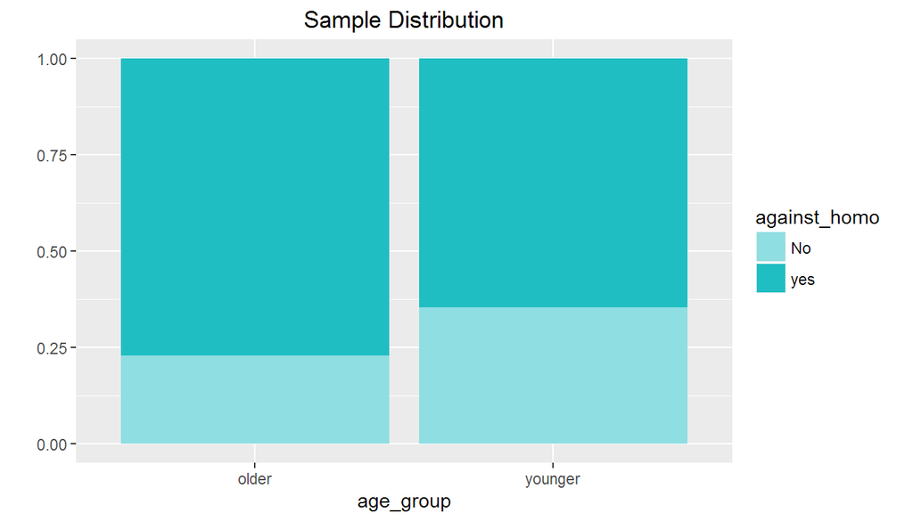

We are 95% confident that the differnece of disapproval rate between older and younger generations is between 11.5% to 13.5%.

**Second**, we will continue out hypothesis test to see if we reject or fail to reject the null hypothesis

```r
inference(y = against_homo, x=age_group, data = sub_df, statistic = "proportion", type = "ht", method = "theoretical", success = "yes", alternative = "greater")
```

```
## Response variable: categorical (2 levels, success: yes)
## Explanatory variable: categorical (2 levels)
## n_older = 16013, p_hat_older = 0.7706
## n_younger = 16675, p_hat_younger = 0.6455
## H0: p_older =  p_younger
## HA: p_older > p_younger
## z = 24.8366
## p_value = < 0.0001
```

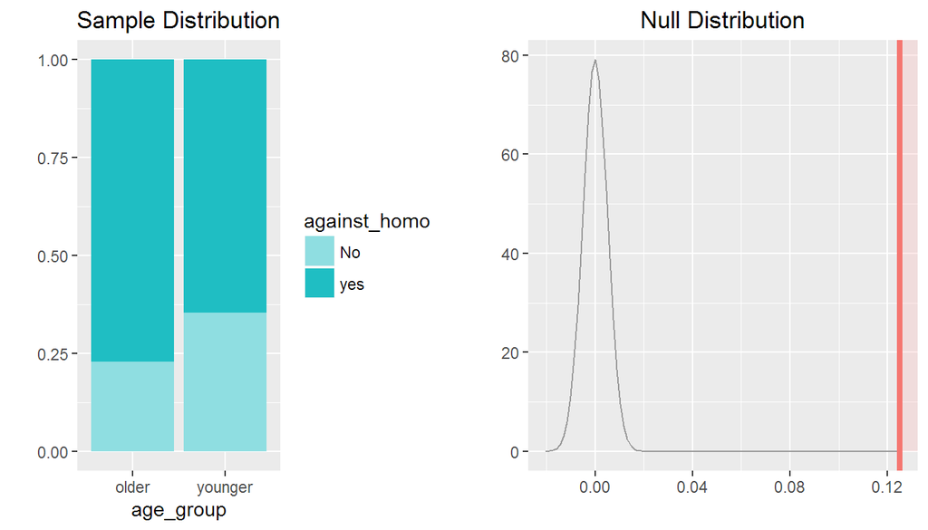

From the above result, we have a **p-value** less than 0.0001. Therefore, we will reject the null hypothesis and conclude that older generations are more opposed to homosexual sex relation than younger generations.